# Funzioni CES

Valerio Calà

9/4/2020

# FUNZIONI CES

Le funzioni di produzione CES hanno elasticità di sostituzione (tra gli input) costante.

Se indichiamo con $Y$ la quantità di output, con $K$ la quantità dell’input capitale e con $L$ quella dell’input lavoro, la seguente equazione esprime la funzione di produzione CES:

$$Y = \gamma [\delta K^{-\rho} + (1-\delta)L^{-\rho} ]^{-\frac{\nu}{\rho}}$$

dove i parametri $(\gamma, \delta, \rho, \nu)$ hanno le seguenti interpretazioni economiche:

$\gamma$ determina la produttività  
$\delta$ determina l’allocazione ottimale degli input  
$\rho$ determina l’elasticità di sostituzione costante: $\sigma = \frac{1}{1+\rho}$  
$\nu$ è l’elasticità di scala: se $\nu > 1$ abbiamo rendimenti di scala crescenti, se $\nu=1$ costanti, altrimenti decrescenti.

Essendo la funzione non-lineare, per stimarla con OLS ordinario si ricorre alla cosiddetta **approssimazione di Kmenta**, che applica prima il logaritmo ad entrambi i lati dell’equazione e poi applica a questa un’espansione di Taylor del primo ordine valutata in $\rho=0$.

Indichiamo con lettere minuscole i logaritmi delle corrispettive variabili:

$y = log(Y)$  
$k = log(K)$  
$l = log(L)$

La funzione di produzione con approssimazione di Kemta diventa quindi una funzione Translog ristretta:

$$y = \alpha_{0} + \alpha_{1}k + \alpha_{2}l + \frac{1}{2}\beta_{11}k^{2} + \frac{1}{2}\beta_{22}l^{2} + \beta_{12}kl$$

con restrizioni $\beta_{11}=\beta_{22}=-\beta_{12}$.

Si può stimare questa equazione con OLS ordinario e poi calcolare i parametri della (vera) funzione CES con le seguenti identità:

$\gamma = exp(\alpha_{0})$  
$\nu = \alpha_{1} + \alpha_{2}$  
$\delta = \frac{\alpha_{1}}{\nu}$  
$\rho = \frac{\beta_{12}\nu}{\alpha_{1}\alpha_{2}}$

Se $\beta_{11}=\beta_{22}=-\beta_{12} = 0$, allora la tecnologia è di tipo *Cobb-Douglas*.

# APPLICAZIONE EMPIRICA: DATI SIMULATI

Simuliamo adesso 1000 di valori casuali per ($K$,$L$) e generiamo $Y$ con i veri valori dei parametri in modo deterministico.  
Poi applichiamo l’approssimazione di Kmenta e vediamo se con OLS ordinario riusciamo ad ottenere delle stime dei parametri sufficientemente vicine ai veri valori.

```r
# simulo 1000 valori casuali per K ed L da una N(100, 10) (media 100, deviazione standard 3)
set.seed(123)
K = rnorm(1000, 100, 3)
L = rnorm(1000, 100, 3)

# ipotizziamo dei (veri) valori per i parametri
gamma = 1
nu = 1.1
delta = 0.6
rho = 0.5

# genero Y applicando la funzione CES
Y = gamma*( delta*K^(-rho) + (1-delta)*L^(-rho) )^(-nu/rho)

# aggiungo un termine di errore white noise N(0,0.01)
Y = Y + rnorm(1000,0,0.01)

# trasformo le variabili applicando la funzione logaritmo
k = log(K)
l = log(L)
y = log(Y)

# genero le variabili 0.5*k^2, 0.5*l^2 e k*l
k2 = 0.5*k^2
l2 = 0.5*l^2
kl = k*l

# OLS con formula y = a0 + a1k + a2l + b11k2 + b22l2 + b12kl
model = lm(y ~ k + l + k2 + l2 + kl)
coefs = coefficients(model)
summary(model)
```

```
##
## Call:
## lm(formula = y ~ k + l + k2 + l2 + kl)
##
## Residuals:
##        Min         1Q     Median         3Q        Max
## -1.774e-04 -4.041e-05 -2.062e-06  4.229e-05  2.202e-04
##
## Coefficients:
##              Estimate Std. Error t value Pr(>|t|)
## (Intercept)  0.085408   0.060461   1.413    0.158
## k            0.646449   0.016425  39.358   <2e-16 ***
## l            0.416450   0.016921  24.612   <2e-16 ***
## k2          -0.133080   0.003252 -40.918   <2e-16 ***
## l2          -0.130882   0.003084 -42.442   <2e-16 ***
## kl           0.136010   0.002210  61.541   <2e-16 ***
## ---
## Signif. codes:  0 '***' 0.001 '**' 0.01 '*' 0.05 '.' 0.1 ' ' 1
##
## Residual standard error: 6.17e-05 on 994 degrees of freedom
## Multiple R-squared:      1,  Adjusted R-squared:      1
## F-statistic: 3.193e+07 on 5 and 994 DF,  p-value: < 2.2e-16
```

```r
# applico le identità ai coefficienti stimati per ricavare i parametri della CES stimati
gamma.hat = exp(coefs[1])
nu.hat = coefs[2] + coefs[3]
delta.hat = coefs[2]/nu.hat
rho.hat = coefs[6]*nu.hat/(coefs[2]*coefs[3])

# confronto i parametri veri con quelli stimati
confronto = data.frame(veri=c(gamma, nu, delta, rho), stimati=c(gamma.hat, nu.hat, delta.hat, rho.hat))
confronto$differenze = confronto$veri - confronto$stimati
confronto
```

```
##   veri   stimati  differenze
## 1  1.0 1.0891609 -0.08916093
## 2  1.1 1.0628989  0.03710105
## 3  0.6 0.6081945 -0.00819453
## 4  0.5 0.5369886 -0.03698859
```

```r
# # root mean squared error e scatterplot
yhat = fitted(model)
Yhat = exp(yhat)
df = data.frame(Y, Yhat)
rmse=sqrt(mean( Y - Yhat )^2)
rmse
```

```
## [1] 3.017652e-07
```

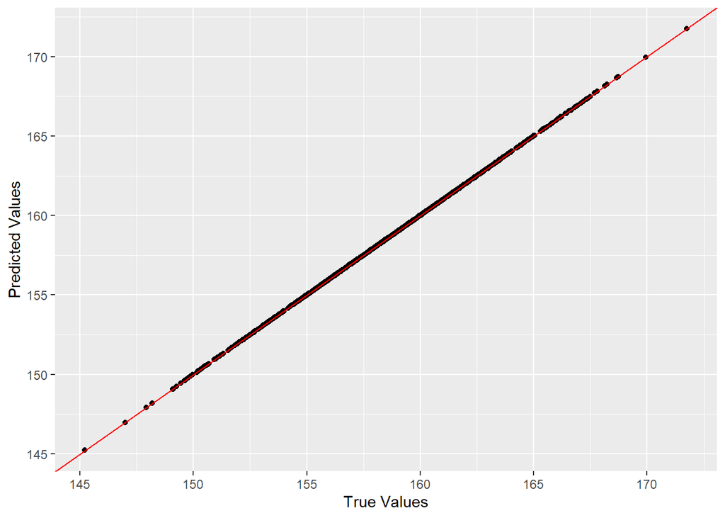

```r
ggplot(data=df, aes(x=Y, y=Yhat)) +
  geom_point() +
  ylab("Predicted Values") +
  xlab("True Values") +
  geom_abline(slope=1, intercept=0, color='red')
```

```r
# package model
dati = data.frame(Y, K, L)

model.ces = cesEst(yName="Y", xNames=c("K","L"), data=dati, method='LM', vrs=T)
summary(model.ces)
```

```
## Estimated CES function with variable returns to scale
##
## Call:
## cesEst(yName = "Y", xNames = c("K", "L"), data = dati, vrs = T,
##     method = "LM")
##
## Estimation by non-linear least-squares using the 'LM' optimizer
## assuming an additive error term
## Convergence achieved after 17 iterations
## Message: Conditions for `info = 1' and `info = 2' both hold.
##
## Coefficients:
##        Estimate Std. Error  t value Pr(>|t|)
## gamma 9.999e-01  4.063e-04  2460.89   <2e-16 ***
## delta 6.000e-01  4.431e-05 13538.73   <2e-16 ***
## rho   5.073e-01  6.455e-03    78.59   <2e-16 ***
## nu    1.100e+00  8.820e-05 12471.77   <2e-16 ***
## ---
## Signif. codes:  0 '***' 0.001 '**' 0.01 '*' 0.05 '.' 0.1 ' ' 1
##
## Residual standard error: 0.009766418
## Multiple R-squared: 0.9999938
##
## Elasticity of Substitution:
##             Estimate Std. Error t value Pr(>|t|)
## E_1_2 (all) 0.663417   0.002841   233.5   <2e-16 ***
## ---
## Signif. codes:  0 '***' 0.001 '**' 0.01 '*' 0.05 '.' 0.1 ' ' 1
```

```r
# confronto stime manuali con stime ottenute dal pacchetto micEconCES
data.frame(ces=coefficients(model.ces), manual=c(gamma.hat, delta.hat, rho.hat, nu.hat), veri=c(gamma, delta, rho, nu))
```

```
##             ces    manual veri
## gamma 0.9999321 1.0891609  1.0
## delta 0.5999530 0.6081945  0.6
## rho   0.5073471 0.5369886  0.5
## nu    1.1000148 1.0628989  1.1
```